# Fine-grained Mosquito Behavioral State Models

FRGS-fine

David Smith

2022-04-26

`~/MosquitoDynamics/MosquitoDynamics.Rmd`

$\uparrow$ Library || Mosquito

## -

We have developed the following model to understand adult mosquito behaviors at a very fine spatial and temporal grain. Some of these models were first developed as part of another project, called Mosquito Dispersal in Context. The goal of this project is to extend that model to describe behaviors at a *smaller* time step. In *Dispersal in Context,* we use a model with three states and on a daily time scale: *F* - Flood feeding; *G* - Gravid, Egg Laying; and $S$ - Sugar feeding. Here, we would like to extend the models to include a resting state, diel patterns, and effects of weather.

- How do temperature, wind, rainfall, relative humidity, and other weather affect the timing of mosquito activity?

## Model

### Diagram

This diagram illustrates the states and flows.

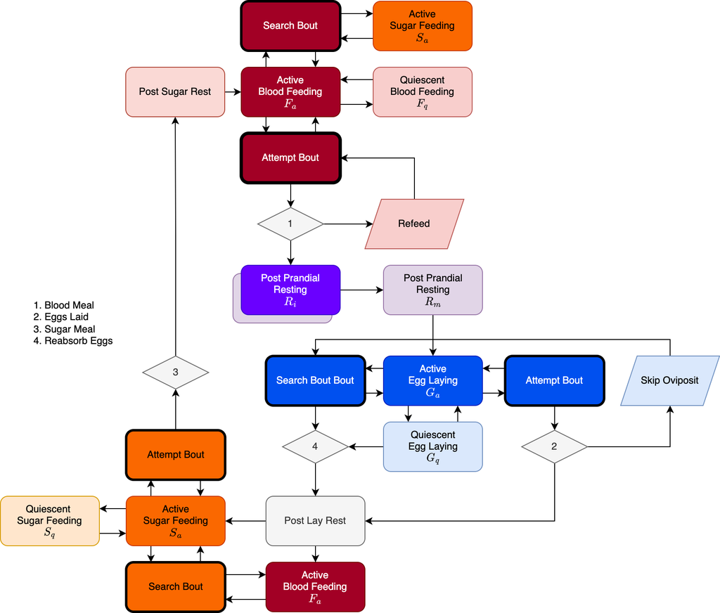

### Variables

We would like to investigate mosquito behaviors affecting vectorial capacity – especially the duration of a feeding cycle – at a very fine temporal grain. We embed this model in a micro-simulation framework, and we let $t$ denote the time, and $d(t)$ the time of day. The processes are to launch

- $F_a$ denotes blood feeding mosquitoes who are active, located at a set of points $\left\{b\right\}$
  - If a host is available ($B_t$), then it will make an attempt to blood feed;
  - If a host is not available, then it will search;
  - With some probability, $\alpha_F$, it remains active; otherwise it becomes quiescent.
  - With some probability, it survives $p_F$

$$F_{a,t+1} = \alpha_F p_F
\left(B_t \left(1-\psi_b\right) + \left(1-B_t \right) M_{bb} \right)
F_{a,t} + A_F(d) F_{q, n, t}$$

$$R_{1,t+1} = \alpha_F p_F B_t \psi_b
F_{a,t}$$

- $F_q$ denotes mosquitoes in the blood feeding state who are quiescent, located at a set of points $\left\{b\right\}.$
  - The quiescent period has a minimal duration.
  - After waiting, the requisite period, the mosquito becomes active again, depending on the time of day.

$$F_{q, 1, t+1} = (1-\alpha_F) F_{a,t}$$

$$F_{q,i+1, t+1} = F_{q,i,t}$$

$$F_{q, n, t+1} = F_{q,n-1,t} + (1-A_F(d))
F_{q, n, t}$$

- $R_q$ denotes a post-prandial, quiescent resting state for mosquitoes, which are located at a set of points where they recently blood fed, $\left\{b\right\}$

$$R_{i+1,t+1} = R_{i,t}$$

$$R_{m,t+1} = R_{m-1,t}+ \left(
1-A_R\left(d\right) \right) R_{m,t}$$

- $G_a$ denotes gravid, egg laying mosquitoes who are active, located at a set of points $\left\{q\right\}$
  - If a habitat is available, then it will make an attempt to blood feed;
  - If a habitat is not available, then it will search.

- $G_q$ denotes gravid, egg laying mosquitoes who are quiescent, located at a set of points $\left\{q\right\}$

$$G_{q, 1, t+1} = (1-\alpha_G) G_{a,t}$$

$$G_{q,i+1, t+1} = G_{q,i,t}$$

$$G_{q, j, t+1} = G_{q,j-1,t} + (1-A_G(d))
G_{q, j, t}$$

- $S_a$ denotes sugar feeding mosquitoes, located at a set of points $\left\{s\right\}$
  - If a sugar source is available, then it will make an attempt to sugar feed;
  - If a sugar source is not available, then it will search.
- $S_r$ denotes gravid, egg laying mosquitoes who are active, located at a set of points $\left\{q\right\}$

We assume that all the parameters are time-dependent, that they are affected by environmental variables.

We start with these equations:

$$\begin{equation}
\begin{array}{ll}
F_{a, t+1} &= M_{sb} \cdot f_t L_{n,t} + (1-f_t) F_t + M_{bb} \cdot
f_t (1-\phi_t) F_t \\ \hline
R_{1,t+1} &= f_t \phi_t F_t \\
R_{i+1,t+1} &= R_{i,t} \\
R_{n,t+1} &= R_{n-1, t} + (1-\nu_t) R_{n,t} \\ \hline
Q_{t+1} &= M_{bq} \cdot \nu_t R_{n,t} + (1-\nu_t) Q_t + M_{qq}
\cdot \nu_t (1-\phi_t) Q_t \\
S_{t+1} &= M_{qs} \cdot \nu_t \phi_t Q_t + (1-\sigma_t) S_t + M_{ss}
\cdot \sigma_t (1-\phi_t) S_t \\ \hline
L_{1, t+1} &= \sigma_t \phi_t S_t \\
L_{i+1, t+1} &= L_{i,t} \\
L_{n, t+1} &= L_{n-1,t} + (1-f_t) L_{n,t} \\
\end{array}
\end{equation}$$